# 聖路加ICU 年次レポート

# 19病床運用

- 正午時点の在室は平均7.1人（3〜8人）。8床に対する利用率は89%で、**満床の日が年間146日**
- 退室が午前10〜11時に鋭く集中し、その時間帯に転棟業務が固まっている
- **在室日数の長い上位10%が、延べ在室日数の41%を占める**

## 19.1日別の在室患者数

図 68日別の在室患者数

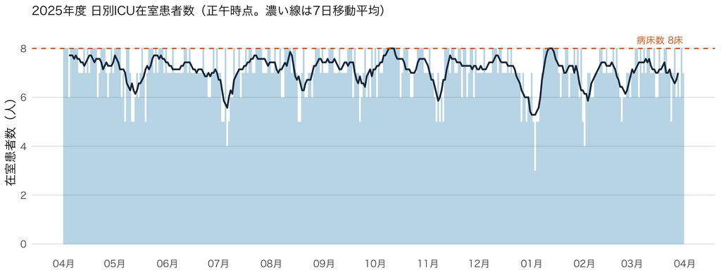

表 38日別の在室患者数

| 指標 | 値 |
| --- | --- |
| 平均在室数（正午時点） | 7.1 人 |
| 中央値 | 7 人 |
| 最大 | 8 人 |
| 最小 | 3 人 |
| 病床利用率（8床） | 89 % |
| 満床の日数 | 146 日 |
| 延べ在室日数 ※ | 3,157 日 |

※ 延べ在室日数は入室日と退室日をどちらも1日と数える（JIPADの在室日数と同じ）。同じ日に退室と入室があると1床で2日分になるため、病床数×日数を上回ることがある。

解説薄い棒が**その日の正午にICUにいた患者数**、濃い線が7日移動平均（前後7日をならした値）、赤い点線が病床数（8床）である。 移動平均を重ねているのは、日々の細かい上下に埋もれず**季節的な傾向があるかどうか**を見るため。

読み取れることは2つある。

1. **季節変動はほとんどない**。移動平均はほぼ水平で、「冬に増える」といった傾向は見られない。 したがって**季節を見込んだ増員計画は不要**
2. 一方で**空きはほとんどない**。平均7.1人は8床に対する利用率89%にあたり、 満床の日が年間146日、残り1床以下（7人以上）の日が293日あった

つまり**繁忙は季節ではなく「日」の単位で来る**。 年間を通じて、**次の緊急入室を受けるには誰かの退室を調整する必要がある日が大半**を占めている。 平均値ではなく満床に近い日を前提に、退室と転棟の段取りを考える必要がある。

## 19.2入退室が集中する時間帯

図 69入退室が集中する時間帯

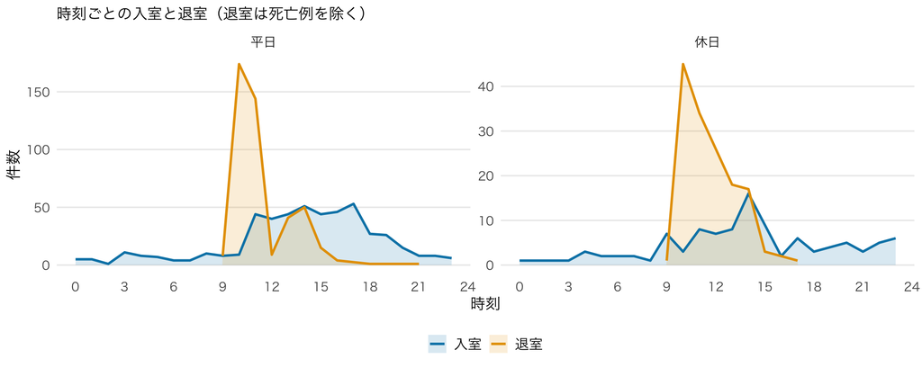

## 19.3長期滞在患者のベッド占有

図 70長期滞在患者のベッド占有

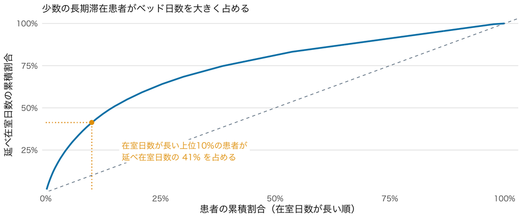

破線（対角線）は「全患者が同じ日数だけ在室した場合」。曲線が対角線から上に離れるほど、 一部の長期滞在患者にベッドが集中していることを意味する。 今年度は上位10%の患者が延べ在室日数の41%、上位20%で58%を占めた。

解説この図は見慣れないと読みにくいので、読み方から。

横軸は**在室日数が長い順に患者を並べたときの累積割合**（左端が最も長く在室した患者）。 縦軸は**その人たちが使ったベッド日数の累積割合**。 仮に全員が同じ日数だけ在室していれば、線は破線（対角線）と重なる。 **線が対角線から上に離れるほど、少数の患者にベッドが偏っている**ことを意味する。

当院の線は急な立ち上がりを見せ、**在室日数が長い上位10%の患者だけで延べ在室日数の41%、上位20%で58%**を占めている。 裏を返せば**残り80%の患者が使っているのは全体の42%にすぎない**。

実務的な含意ははっきりしている。 **長期滞在の患者を1人減らす効果は、短期入室を数人減らす効果より大きい**。 病床を空けたいときに短期入室を絞っても効きにくく、長期滞在側に手を入れるほうが合理的である。

# 20特定集中治療室管理料の算定

- **急性血液浄化・ECMOを要した患者は算定上限が14日→25日に延びる**（令和4年度改定で新設）
- 制度開始から4年間で**のべ67例・510日分**、現行のDPC点数に換算して**約5937万円**にあたる
- 今年度単独では18例・130日分・約1513万円
- 単価は**DPC点数 11,641点／日（116,410円）**。当院はほぼ全例DPCのため、出来高点数ではなくこちらを使う
- **JIPADへの症例登録がこの延長算定の施設基準そのもの**（令和4年度 疑義解釈 問94）。登録をやめれば増収は失われる
- 管理料の**算定率**は年平均74.9%（前年度 75.0%）。在室日数の約25%は算定できていない
- 医事課集計の**機会損失額**（管理料を算定できなかった分）は年間約7,059万円（前年度 7,397万円）

特定集中治療室管理料は原則14日が算定の上限だが、**急性血液浄化（腹膜透析を除く）または体外式心肺補助（ECMO）を必要とする患者**は **25日**まで算定できる（臓器移植を行った患者は30日）。この延長は**令和4年度診療報酬改定で新設**された。

**そしてこの延長を算定するための施設基準が、JIPADへの症例登録である。** つまり以下の金額は、**JIPADに症例を登録し続けていることで初めて成立している**ものである（根拠は章末に示す）。 制度開始から現在まで、どれだけの算定につながったかを試算する。

表 39特定集中治療室管理料の算定

| 項目 | 値 |
| --- | --- |
| 対象となった症例数 | 18 例 |
| 延長により算定できた日数 | 130 日 |
| 1日あたりの管理料（DPC点数） | 11,641 点（116,410 円） |
| （参考）出来高点数 | 13,371 点（133,710 円） |
| 増収額（試算） | 約 15,133,300 円 |

解説**急性血液浄化またはECMOを要した18例で、合計130日分の算定日数が上限延長によって確保された。** 金額にすると約1513万円で、**ICU全体の年間収入から見れば大きくはないが、18例という少数から生まれている点が重要**である。 1例あたりでは平均7.2日、最大11日の延長になる。

## 20.1制度開始からの推移

表 40制度開始からの推移

| 年度 | 対象症例数 | 延長算定日数 | 増収額（試算） |
| --- | --- | --- | --- |
| 2022年度（令和4年度） | 18 例 | 128 日 | 14,900,480 円 |
| 2023年度（令和5年度） | 13 例 | 106 日 | 12,339,460 円 |
| 2024年度（令和6年度） | 18 例 | 146 日 | 16,995,860 円 |
| 2025年度（令和7年度） | 18 例 | 130 日 | 15,133,300 円 |
| 4年間の累計 | 67 例 | 510 日 | 59,369,100 円 |

図 71制度開始からの推移

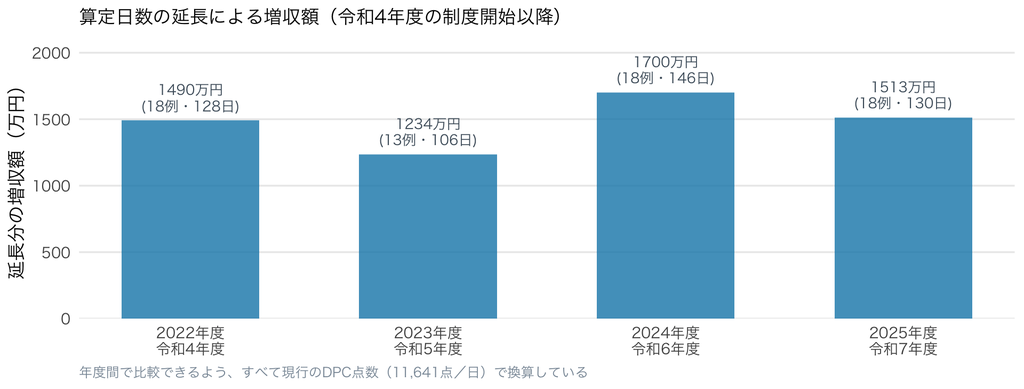

解説制度開始から4年間で**のべ67例・510日分、現行のDPC点数換算で約5937万円**にあたる。 年度別では1234万〜1700万円と幅がある。 **該当症例が年13〜18例と少ないため、数例の増減で金額が大きく動く**。 安定した収入源として見込むのではなく、**重症例を引き受けた結果として付随する**ものと理解するのが妥当である。

なお参考までに、制度が無かった2020〜2021年度にも同条件の症例は 21例あり、 **当時は14日を超えた分を算定できていなかった**ことになる。

この試算の前提と注意点

- **点数**：特定集中治療室管理料1（令和8年度改定）の**15〜25日のDPC点数 11,641点／日**で計算した（医事課確認）。延長分はすべてこの区分に入る
- **過去年度も現行点数で換算**：年度間の比較を症例数の増減だけで見られるようにするため。実際に当時算定した金額は、その年度の点数（令和4・6年度はより低い）で計算されるので**これより少ない**
- **臓器移植（30日）は対象外**：本レポートのデータでは移植症例を判別できないため、25日の延長分のみを計上した
- **上限日数**：急性血液浄化（腹膜透析を除く）またはECMOを要する患者は25日が限度。原則の14日との差分を「延長分」とした
- **腹膜透析の扱い**：本レポートの「間欠腎代替療法」はJIPADの定義上**腹膜透析を含む**。腹膜透析は延長の対象外のため、上記は**やや過大に出ている可能性**がある
- **重症度・看護必要度の要件**：実際の算定可否は日々の重症度評価にも左右される。ここでは在室日数と治療内容のみで機械的に計算した
- **DPCの扱い**：当院は特定機能病院でDPC対象であり、ICUに入室する患者もほぼ全例DPCで算定している。 DPCでは特定入院料を**医科点数表（出来高）の点数ではなく、DPC独自に定められた点数**として包括点数に加算する （入院基本料や検査・投薬など、包括範囲が重なる分が調整済みの点数）。 本レポートはDPC点数で計算している。出来高点数（13,371点）で計算すると 約1738万円となり金額は大きく出るが、実態からは離れる
- **コロナ特例の期間**：2020〜2022年度は新型コロナ患者に算定日数の特例があり、通常のルールと異なる。 この期間の年度比較はそのまま読まないこと
- **院内の実際の算定実績とは必ず突き合わせること。** この試算は「上限延長が効いた規模感」を示すもので、請求額そのものではない

この延長算定はJIPADへの症例登録が要件になっている

算定上限日数の延長には施設基準が定められており、次の2つを満たす必要がある。

1. 当該治療室において**「早期離床・リハビリテーション加算」または「早期栄養介入管理加算」の届出**を行っていること
2. 当該治療室に入院する患者について、**関連学会と連携の上、適切な管理等を行っている**こと

このうち2の「関連学会と連携」について、令和4年度改定の疑義解釈（問94）は次のように明示している。

> 日本集中治療医学会のデータベースである **JIPAD（Japanese Intensive care Patient Database）に症例を登録し、治療方針の決定及び集中治療管理を行っている**ことを指す。

つまり**JIPADへの症例登録は、この延長算定を行うための施設基準そのもの**である。

### 登録をやめた場合の損失

「登録をやめても入院料は取れるのだから、失われるのは差額だけではないか」という見方がある。 **出来高で算定する病院ならそのとおり**で、特定入院料は入院基本料を内包しているため、 算定できなくなれば入院基本料に戻り、失われるのはその差額になる。

**当院はDPC対象（特定機能病院）なので構造が違う。** 15日目に何が起きるかを2つ並べると分かりやすい。

表 41登録をやめた場合の損失

|  | 15日目にもらえるもの |
| --- | --- |
| **JIPADに登録している（延長算定できる）** | DPCの診断群分類点数（包括点数） **＋ 特定集中治療室管理料1 11,641点** |
| **登録していない（15日目で打ち切り）** | DPCの診断群分類点数（包括点数）**のみ** |

つまり「15日目以降にもらえる入院費用」の正体は**その患者のDPC包括点数**であり、 これは**管理料を算定できてもできなくても同額**である。ICUに寝ていても一般病棟に移っても変わらない。 両方のシナリオに同じだけ入るので、引き算すると消える。 差として残るのは**管理料の11,641点＝116,410円／日、まるごと**になる。

**引き算そのものは、11,641点という数字を作る段階で制度側が済ませている。** DPCで加算する特定入院料は**医科点数表（出来高）の点数ではなく、DPC独自に定められた点数**で、 包括範囲が重なる分（入院基本料相当・検査・投薬など）があらかじめ差し引かれている。

出来高の病院とDPCの病院は、**同じ引き算を別の場所でしている**にすぎない。 出来高の病院は請求のたびに自分で引き（管理料13,371点 − 特定機能病院入院基本料7対1 2,146点 ＝ 11,225点）、 DPCの病院は引いた後の点数（11,641点）を受け取る。着地点はほぼ同じである。 **当院はDPCなので、11,641点からさらに入院基本料を引く必要はない。**

なお控除額は、1〜14日が2,235点なのに対し**15日目以降は1,730点と小さくなる**。 入院期間が延びるとDPCの包括点数が逓減し、重なる部分が減るためと考えられる。 結果として**延長で算定できる15〜25日目の単価（11,641点）は、通常の8〜14日目（11,136点）より505点／日 高い**。 延長算定は「打ち切りを免れる」だけでなく、単価の面でもわずかに有利に働いている。

管理料1の単価は次のとおりで、**本レポートは左のDPC点数を使う**。 出来高点数のほうが金額は大きく出るが、**当院はICU入室患者がほぼ全例DPCのため、実際の収益に近いのはDPC点数**である （院内の会議資料や年会費の稟議もDPC点数で作成している）。

表 42登録をやめた場合の損失

| 算定期間 | DPC点数（本レポートで使用） | 出来高点数 |
| --- | --- | --- |
| 1〜7日 | 12,745 点 | 14,980 点 |
| 8〜14日 | 11,136 点 | 13,371 点 |
| **15〜25日（延長分）** | **11,641 点＝116,410 円** | 13,371 点 |
| 26〜30日 | 11,641 点 | 13,371 点 |

**登録をやめれば、上記の増収はそのまま失われる。** 日々の登録作業は事務負担ではあるが、**その負担に対して金額で示せる裏づけがある**数少ない例といえる。

## 20.2病床利用率と算定率

医事課が毎月集計している**ICU病床利用率**と**特定入院料の算定率**（ICUの在室日数のうち特定集中治療室管理料を算定できた日の割合）を、 年度ごとに比べる。月別の値は医事課のグラフから読み取った近似値（±1ポイント程度）で、年平均は医事課の表示値である。

図 72病床利用率と算定率

[interactive chart not shown]

解説算定率の年平均は2024年度75.0%、2025年度74.9%と、 **ICUの在室日数の約25%は管理料を算定できていない**。 月ごとの振れは大きく、2025年度は7月の約60%から1月の約89%まで動いた。

病床利用率は2024年度93.4%から2025年度90.2%へ下がった。 台帳から数えた正午時点の在室（8床に対して89%、病床運用の章）ともよく合っている。

## 20.3算定できなかった管理料（機会損失額）

同じく医事課が毎月集計している**ICU特定入院料の機会損失額**（管理料を算定できなかった分の金額）を比べる。

図 73算定できなかった管理料（機会損失額）

[interactive chart not shown]

表 43算定できなかった管理料（機会損失額）

| 年度 | 年間合計 | 月平均 | 月の最小〜最大 |
| --- | --- | --- | --- |
| 2024年度 | 7,397 万円 | 616 万円 | 369 万円〜943 万円 |
| 2025年度 | 7,059 万円 | 588 万円 | 257 万円〜953 万円 |

解説2025年度の機会損失額は年間**約7,059万円**で、 前年度の約7,397万円から**338万円（4.6%）減った**。 ただし月ごとの振れ幅が大きく（2025年度は257 万円〜953 万円）、1年分の差だけで改善とは言い切れない。

機会損失額は前節の算定率と**表裏の関係**にある。算定率が最も低かった7月は機会損失額も 953 万円と大きく、算定率が最も高かった1月は257 万円にとどまった。 算定率を上げる打ち手を考えるには、次は**算定できなかった日の理由（算定上限の超過・基準を満たさない等）の内訳**を医事課と確認したい。

# 21付録 主要項目の入力率

- 本レポートの数字がどれだけの入力率の上に成り立っているかを、**主要項目・年度別に開示**する

表 44付録 主要項目の入力率

| 項目 | 2020 | 2021 | 2022 | 2023 | 2024 | 2025 |
| --- | --- | --- | --- | --- | --- | --- |
| 主病名（疾患群名） | 97% | 97% | 99% | 99% | 97% | 96% |
| APACHE IIIスコア | 100% | 100% | 100% | 100% | 100% | 100% |
| 退院時転帰 | 99% | 100% | 100% | 100% | 99% | 99% |
| HFNC | 100% | 100% | 100% | 100% | 100% | 100% |
| NPPV | 100% | 100% | 100% | 100% | 100% | 100% |
| せん妄の有無 | 100% | 100% | 100% | 100% | 100% | 100% |
| Charlson Risk Index | 42% | 95% | 93% | 92% | 88% | 96% |
| Clinical Frailty Scale | 36% | 69% | 93% | 46% | 30% | 93% |
| 栄養開始までの時間 | 68% | 69% | 64% | 62% | 61% | 53% |
| 早期リハビリ開始日時 | 4% | 18% | 21% | 21% | 18% | 20% |
| 早期離床加算の算定有無 | 0% | 0% | 0% | 0% | 0% | 100% |
| 栄養摂取量（エネルギー） | 69% | 88% | 82% | 88% | 78% | 87% |
| 人工呼吸器時間 | 0% | 17% | 14% | 17% | 20% | 15% |

解説数字の信頼度を判断する材料として、主要項目が「どれだけ埋まっているか」を年度別に示した。 患者背景・重症度・転帰といった台帳の基本項目は高い入力率で安定しており、本レポートの主要な結論はこれらに基づいている。

一方、**栄養の開始時刻とリハビリ関連は入力率が低い**。 2025年度は再入力により**Clinical Frailty Scaleが93%、Charlson Risk Indexが96%まで揃った**。 過去年度と比べて急に上がっているのは診療の変化ではなく記録の整備によるもので、**この2項目は経年で比べないこと**。

栄養は「48時間以内に開始できなかった理由」が記録されるようになり、記録の有無と開始の有無を切り分けられるようになった。 一方**リハビリの開始日時は依然として記録が少ない**。早期離床率（48時間以内）はこの記録がある例だけで算出しているため、 **開始日時の入力を増やすことが、この指標の信頼度を上げる一番の近道**である。 加算の算定有無は全例に記録があるが48時間以内かどうかを問わないため、参考値として併記している。

聖路加ICU 年次レポート 2025年度 |